# PEAR - Biodiversidade & Ecossistemas

# Exposição

Refere-se à presença, distribuição e proximidade de elementos que são alvo de possíveis impactos climáticos, neste caso, elementos que compõem a integridade do bioma. A exposição a uma ameaça particular pode ser determinada independentemente da vulnerabilidade. O Índice de Exposição é composto pelo indicador temático: Cobertura natural exposta.

## Indicador temático - Cobertura natural exposta

Cobertura natural exposta pode afetar a integridade do bioma, pois a maior exposição da cobertura natural pode reduzir a estrutura e funcionamento dos ecossistemas. O indicador temático Cobertura natural exposta é resultante da composição dos indicadores simples: Área protegida; Cobertura florestal ou formação natural não florestal; e Área prioritária para conservação.

Refere-se à presença, distribuição e proximidade de elementos que são alvo de possíveis impactos climáticos, neste caso, elementos que compõem a integridade do bioma. A exposição a uma ameaça particular pode ser determinada independentemente da vulnerabilidade. O Índice de Exposição é composto pelo indicador temático: Cobertura natural exposta.

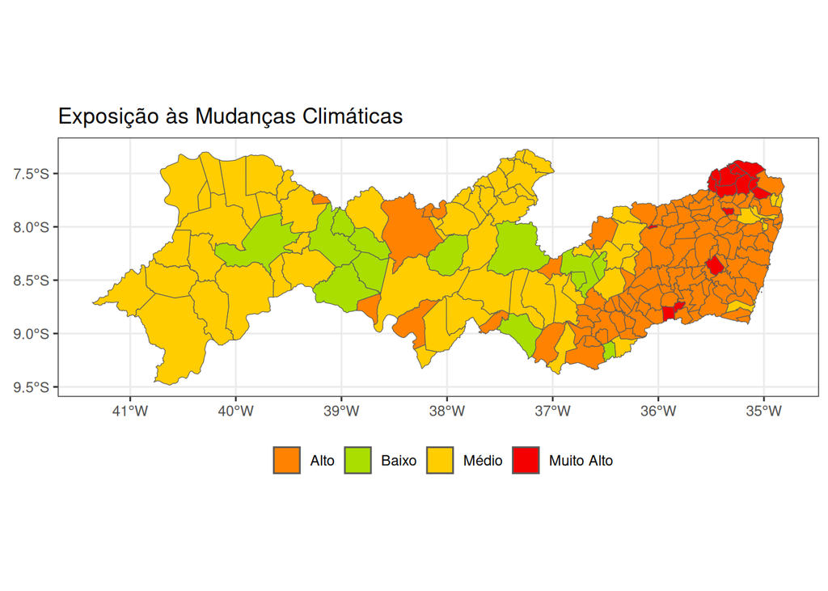

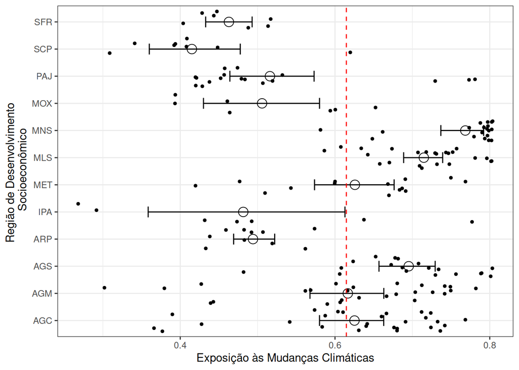

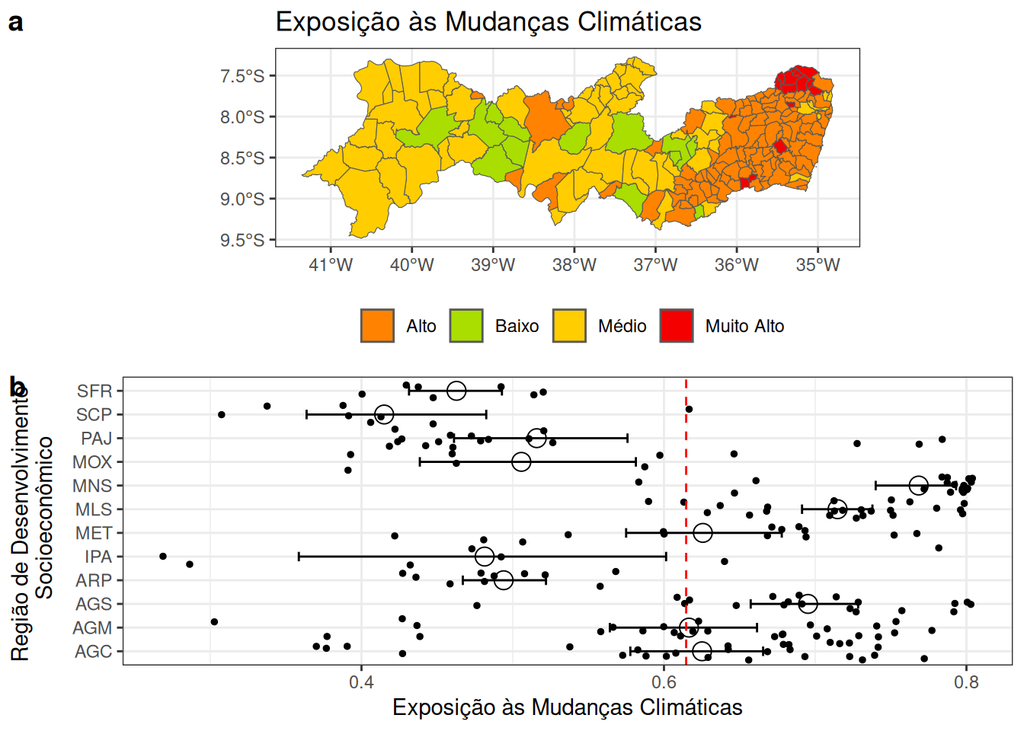

**Conclusão**: Poucas UCs e de baixa implementação (falta de comitê gestor) não ajudam na capacidade adaptativa dos bioma frente às mudanças climáticas.

### Indicadores individuais - Exposição

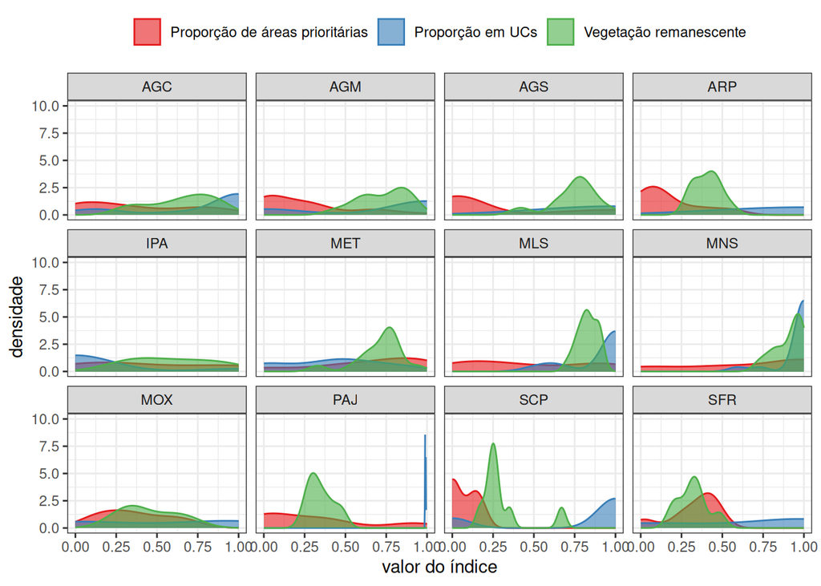

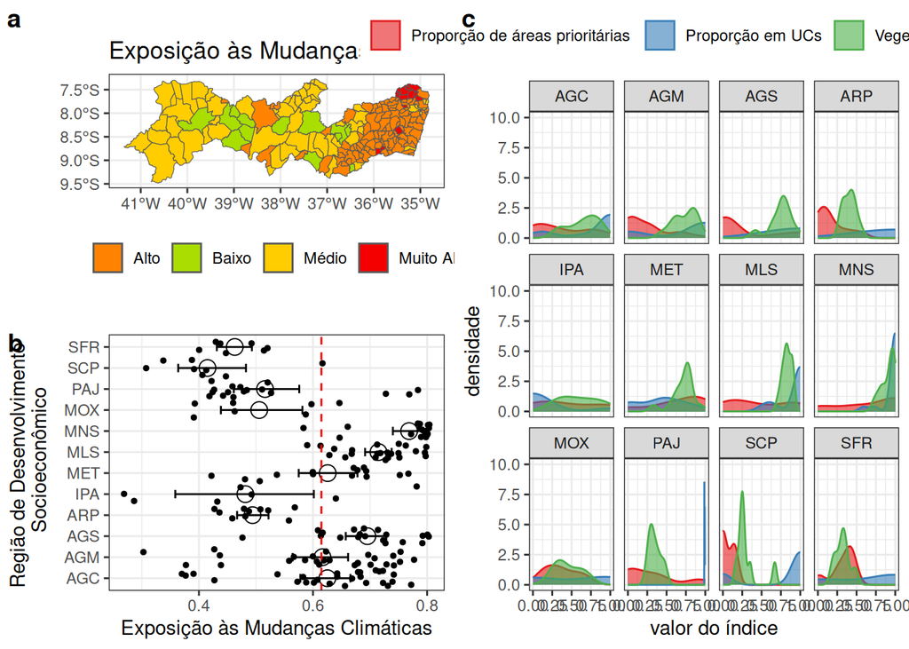

# Valores médios de Vulnerabilidae pro RDS

$$Vulnerabilidade = Sensibilidade+Exposição-Capacidade adaptativa$$

Grau de suscetibilidade do bioma a uma determinada ameaça climática. A vulnerabilidade refere-se às características que um determinado ecossistema possui que refletem à suscetibilidade dele em relação às variações climáticas que podem afetar, direta ou indiretamente, a integridade do bioma. A vulnerabilidade está vinculada a situação de sensibilidade e capacidade adaptativa desse sistema, ou seja, se baseia em fatores conjunturais existentes antes do impacto climático. (Fonte: Adapta Brasil)

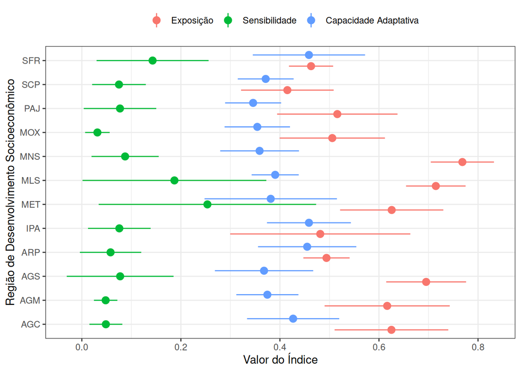

Nota-se aqui vários padrões:

1. Exposição é bastante variável entre e dentro das RDS, sugerindo que os municípios possuem contextos muito distintos que aumentam ou diminuem sua exposição ao risco climático
2. Sensibidade possui menor variação entre RDS mas algumas delas são compostas por municípios muito discrepantes (p.ex. MET e MLS )
3. A capacidade adapttiva é bastente uniforme entre as RDS com menor variação entre e dentro dos grupos, provavelmente indicando poucas variações nos indicadores individuais.

# Risco Climático

## Risco climático atual e projetado

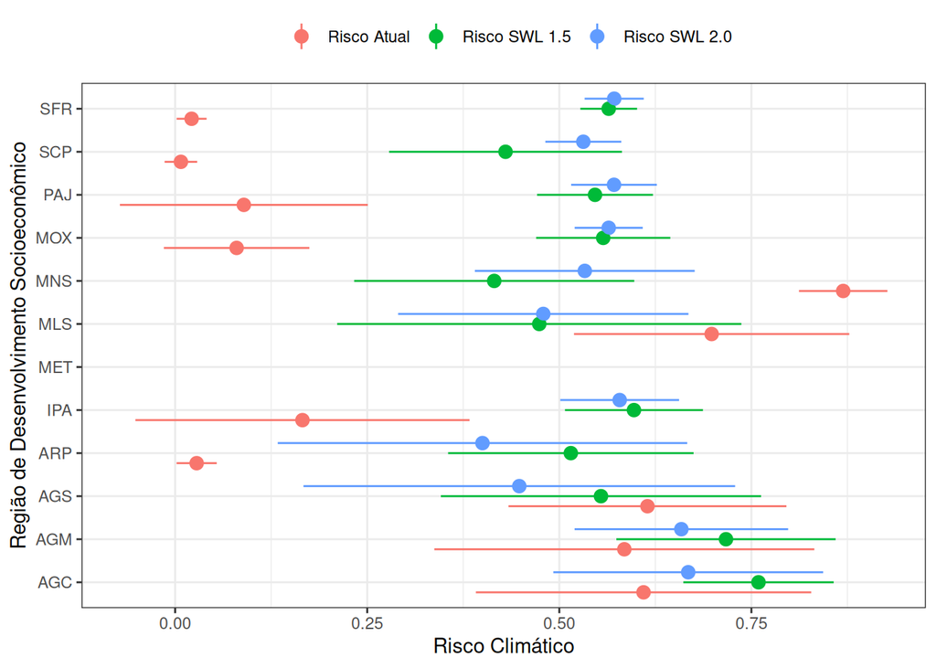

# Ameaça à Integridade do Bioma

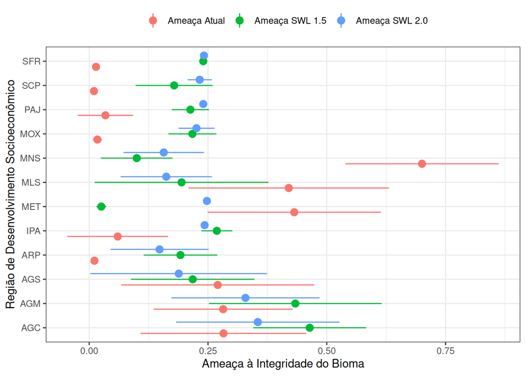

# Análises para as oficinas nas RDs

Nesta sessão o objetivo é criar resumos analíticos e recomendações técnicas para a condução das oficinas. É importante salientar que praticamente todas essas infromações estão disponíveis na [Plataforma Adapta Brasil](https://adaptabrasil.mcti.gov.br/), de forma interativa e muito fácil de usar e entender.

## Cuidados com a interpretação por RDs

O Governo de PE solicitou que essas análises fossem agrupadas por RDs de forma que a atuação do poder público replicasse a divisão do estado em regiões de desenvoilvimento. No entanto, é crucial copreender que apesar de não totalmente arbitrária, a divisão dos numicípiops de PE em RDs é artificial e portanto não e esperado que esses municípios se comportem de maneira similar para todos os indicadores, ainda que alguns serão similares sempre que o comportamento dessas variáveis sejam espacialmente determinado ou socioeconomicamente definido de acordo com características geográficas locais. Portanto, mesmo os resumos por RD precisam ser interpretados não só no seu padrão médio, mas na sua variação. É possível que muitas vezes, a variação seja ainda mais elucidativa que um valor médio que pode esconder discrepâncias importantes entre municípios da mesma RD.

## Esquema proposto para a Biodviersidae